# Analysis and visualization of Indian Premeir League(IPL)

# Investigation overview

In this Investigation, i wanted to look at the features of players that could be used to predict the player performances. The main focus was on the features like 'Batsman', 'Batsman_runs', 'Bowler', 'Player_dismissed' from delivery data and features like 'winner' and 'player_of_match' from matches data

# Dataset Overview

The data sets delivery and matches consists of 15460 ball by ball data and 636 matches with attributes include'Batting_team', 'Bowling_team', 'Season' and 'winner'. Few of these attributes are used for the analysis and visualization

# Analysis and Visualization

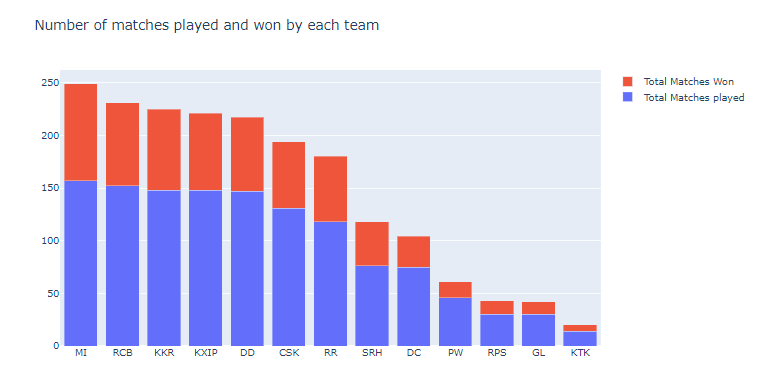

The second Visualization shows the man of the match in IPL. It is evident that player named Chris Gayle has 18 man of the match awards followed by 16 ,15 by Yk Pathan and DA Warner, AB Devilliers. Man of the match describes its "one man show" in a team that contributed more for team winning

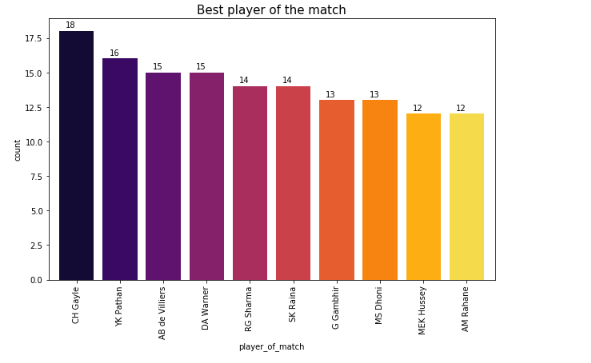

The Third visualization shows the top 15 batsman in the IPL. Sk Raina tops the list with more than 4500 runs scored and V kohli followed by second and RG sharma third respectively. This analysis helps to look that these players are helpful in making their team winning by scoring high runs  
Key insight: Best Batsmans are best scorers, to stop(caught) them on field are Best bowlers because they know where to bowl them like targetting their weaker areas

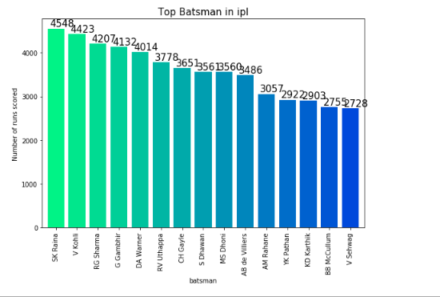

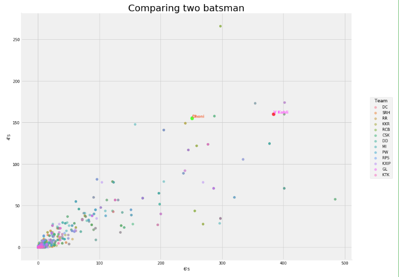

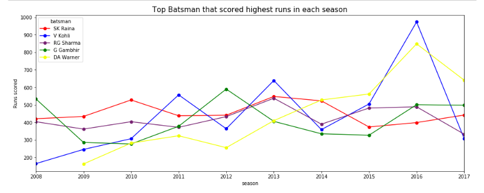

When it comes to Batting performances in death(last 5 overs to be called) teams like MI and RCB finished scoring high runs when compared to other teams  
Keyinsight: High scoring players at death also be dismissed at the early stage otherwise they end up finishing a great target.

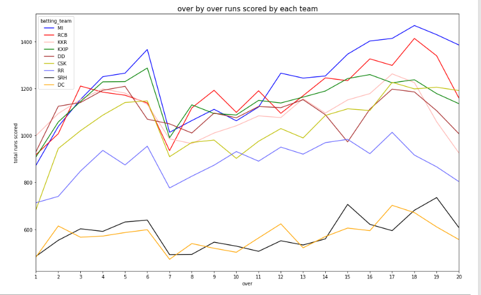

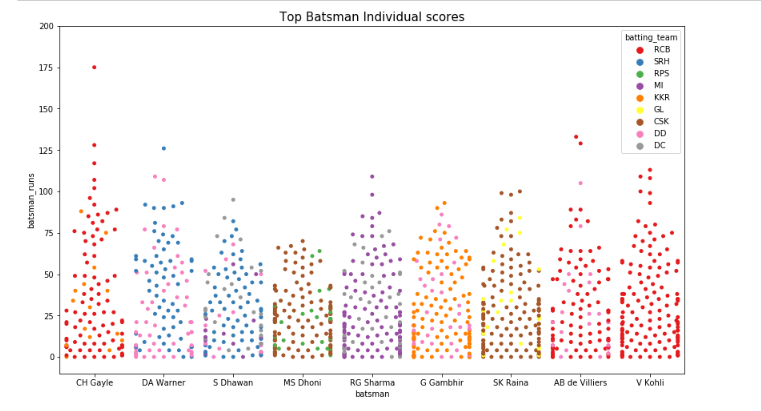

This bar graph shows the top 15 bowlers in IPL. Malinga picked more than 150 plus wickets.  
Key insight:we can estimate that these bowlers can defend the situation where 8 runs required in 6 balls and make their team winning

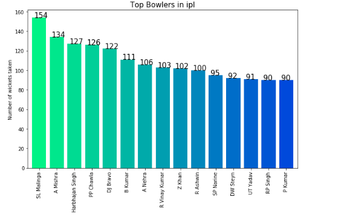

Here is an great visualization that shows the top ten bowlers in IPL. Of course again malinga tops the list but there is economy(It is number of runs conceeded in over like less economy means great bowler and more economy means easy to play) who has less than 6.5 where it becomes to difficult play in R Ashwin over. whereas player named Vinay kumar has high economy 8 (easy to play) but he picked the wickets as well  
key insight: Less economy bowlers are best utilized to bowl at death(last 5 overs) to prevent high scoring runs. So many teams keep their key bowlers to bowl at the death.

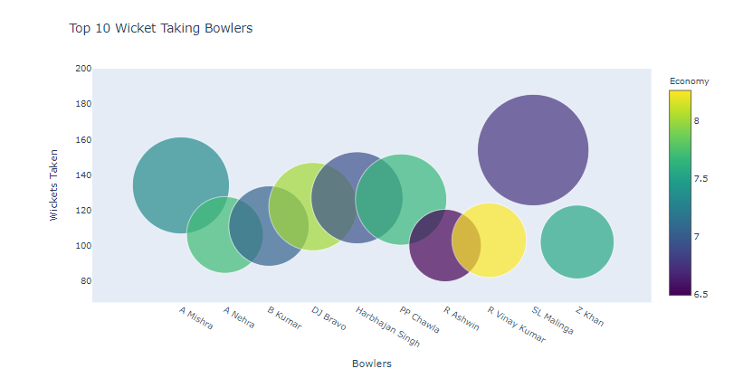

# Conclusion

Indian premier league is a T-20 format cricket League which is played every year in India since 2008. The management of 8 different teams, auction the players to make a good team.Player Analysis(Batting and Bowling) help franchises, sponsors, cricket selectors and cricket-boards of different countries to make a good team prediction. They rely on player analysis for good decision making in team, which player to be auctioned, and at what price the player to be auctioned. Sponsors for advertising their products prefer player analysis and pick a player at the beginning stage of his career, which helps them in future for the endorsements . Cricket team selection committees also prefer player analysis to make the probable eleven key players for the upcoming series and major league tournaments. I have learned player analysis in cricket is very important for making decisions in player selection, franchises to auction and make a team, sponsors for their endorsements, Team Managements for picking best eleven players. These analysis are helpful to selectors where they can pick the best eleven players that includes Batsman and Bowlers.